# Exploring the BRFSS data

## Setup

### Load packages

```r
library(ggplot2)
library(dplyr)
```

### Load data

Make sure your data and R Markdown files are in the same directory. When loaded your data file will be called `brfss2013`. Delete this note when before you submit your work.

```r
load("brfss2013.RData")
```

## Part 1: Data

The Behavioral Risk Factor Surveillance System (BRFSS) is a collaborative project between all of the states in the United States (US) and participating US territories and the Centers for Disease Control and Prevention (CDC). The BRFSS is administered and supported by CDC’s Population Health Surveillance Branch, under the Division of Population Health at the National Center for Chronic Disease Prevention and Health Promotion. BRFSS is an ongoing surveillance system designed to measure behavioral risk factors for the non-institutionalized adult population (18 years of age and older) residing in the US. The BRFSS was initiated in 1984, with 15 states collecting surveillance data on risk behaviors through monthly telephone interviews. Over time, the number of states participating in the survey increased; by 2001, 50 states, the District of Columbia, Puerto Rico, Guam, and the US Virgin Islands were participating in the BRFSS. Today, all 50 states, the District of Columbia, Puerto Rico, and Guam collect data annually and American Samoa, Federated States of Micronesia, and Palau collect survey data over a limited point- in-time (usually one to three months). In this document, the term “state” is used to refer to all areas participating in BRFSS, including the District of Columbia, Guam, and the Commonwealth of Puerto Rico.

The BRFSS objective is to collect uniform, state-specific data on preventive health practices and risk behaviors that are linked to chronic diseases, injuries, and preventable infectious diseases that affect the adult population. Factors assessed by the BRFSS in 2013 include tobacco use, HIV/AIDS knowledge and prevention, exercise, immunization, health status, healthy days — health-related quality of life, health care access, inadequate sleep, hypertension awareness, cholesterol awareness, chronic health conditions, alcohol consumption, fruits and vegetables consumption, arthritis burden, and seatbelt use. Since 2011, BRFSS conducts both landline telephone- and cellular telephone-based surveys. In conducting the BRFSS landline telephone survey, interviewers collect data from a randomly selected adult in a household. In conducting the cellular telephone version of the BRFSS questionnaire, interviewers collect data from an adult who participates by using a cellular telephone and resides in a private residence or college housing.

Health characteristics estimated from the BRFSS pertain to the non-institutionalized adult population, aged 18 years or older, who reside in the US. In 2013, additional question sets were included as optional modules to provide a measure for several childhood health and wellness indicators, including asthma prevalence for people aged 17 years or younger.

- About BRFSS and its generalizability

Random Sampling is fine but telephone surveys tend to have high non-response rates, and a group of voluntary responses could account to some bias.

It may also happen that participants do not honestly answer some of the sensitive questions in the questionnaire with regards to their health status, which carries the risk of a response bias.

- About BRFSS and causality

BRFSS is an observational study. Therefore, it can’t be used to make causal inferences from the data.

## Part 2: Research questions

**Research question 1:**

Is having a medical checkup conducted recently and general health(genhlth) correlated?

**Research question 2:**

Does gender affect drinking any alcoholic beverages in the past 30 days?

**Research question 3:**

Extending the 2nd question, does the income bracket have any effects?

## Part 3: Exploratory data analysis

**Research question 1:**

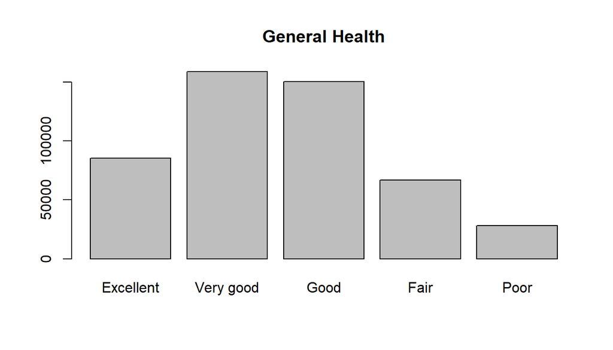

```r
 plot(brfss2013$genhlth)
 title(main="General Health")
```

```r
 df=data.frame(summary(brfss2013$checkup1))
 df
```

```
##                     summary.brfss2013.checkup1.
## Within past year                         356228
## Within past 2 years                       57298
## Within past 5 years                       33674
## 5 or more years ago                       33748
## Never                                      4522
## NA's                                       6305
```

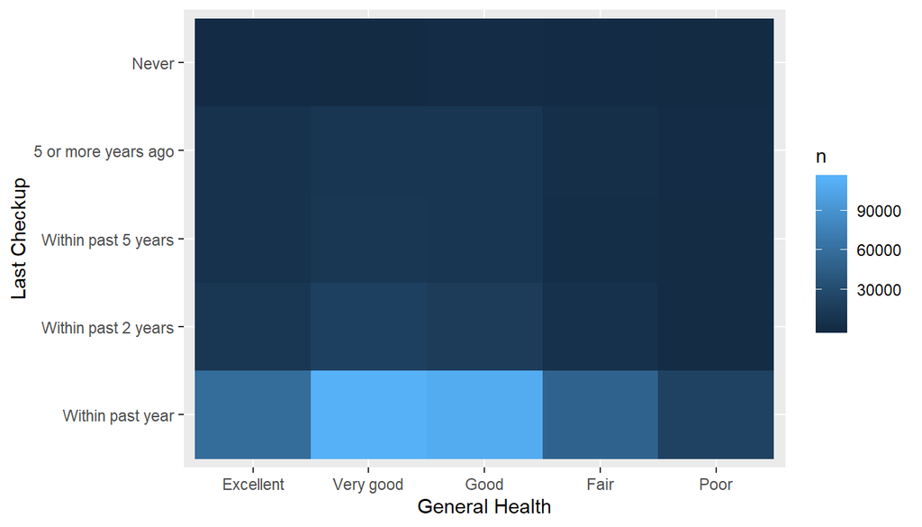

```r
brfss2013 %>%
  filter(!is.na(genhlth) & !is.na(checkup1)) %>%
  count(genhlth, checkup1) %>%
  ggplot(mapping = aes(x=genhlth, y=checkup1))+
  geom_tile(mapping = aes(fill=n))+xlab("General Health")+ylab("Last Checkup")
```

People tend to have a better general health(genhlth) those who have had a checkup with the past year.

**Research question 2:**

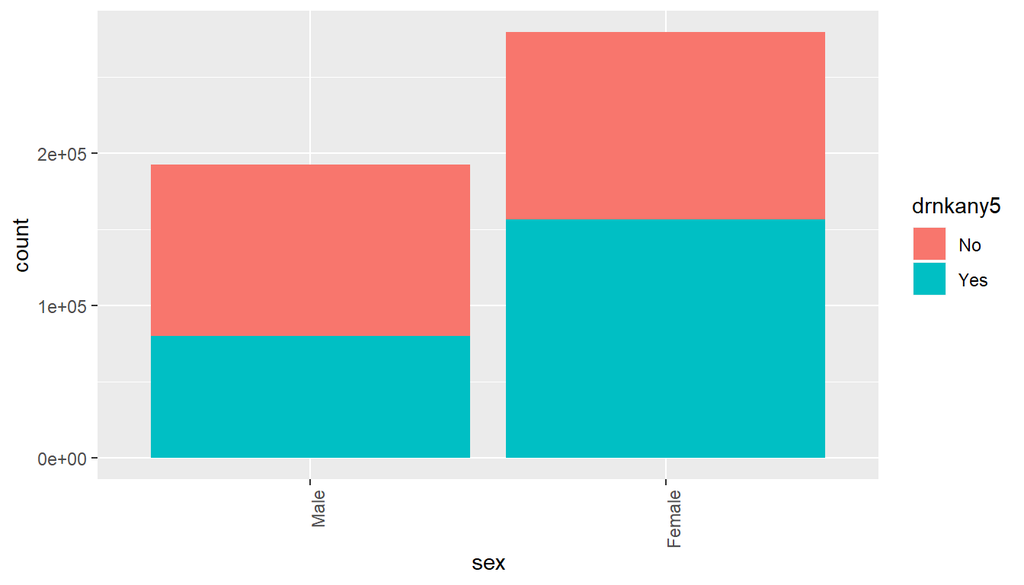

```r
q2 <- select(brfss2013,sex, drnkany5 ) %>%
  filter(!is.na(sex), !is.na(drnkany5)) %>% group_by(sex)
g <- ggplot(q2, aes(sex))
g + geom_bar(aes(fill =drnkany5))+ theme(axis.text.x = element_text(angle = 90, vjust = 1, hjust=1))
```

Gender(sex) does affect drinking any alcoholic beverages in the past 30 days(drnkany5).

**Research question 3:**

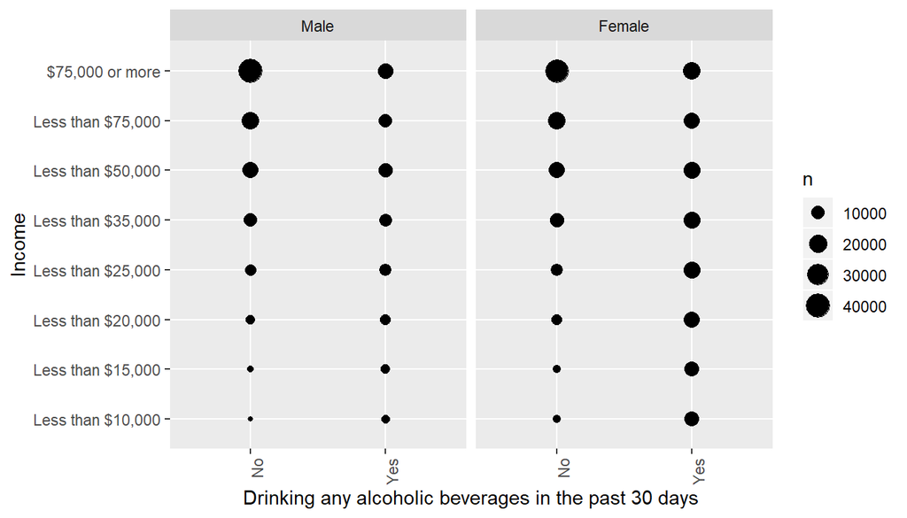

```r
q3 <- select(brfss2013,drnkany5, income2, sex) %>%
  filter(!is.na(drnkany5), !is.na(sex), !is.na(income2))
ggplot(data = q3, aes(x = drnkany5 , y = income2 ))+
     geom_count () +
   theme(axis.text.x = element_text(angle = 90, vjust = 1, hjust=1))+
   facet_grid(. ~  sex) +
     xlab("Drinking any alcoholic beverages in the past 30 days") +
     ylab ("Income")
```

We can observe that as the income bracket is increasing there is an increasing consciousness among people not to drink alcohol.